# Homework 2 STAT 4500

Cody Frisby

## 4.1

First we take a look at the empirical CDF of our data after being normalized with the normal CDF overlayed in red:

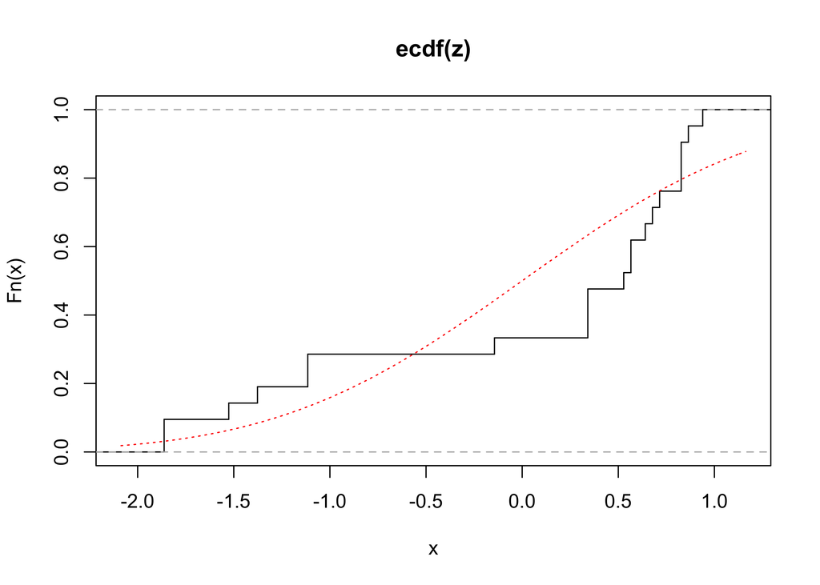

At first glance, this does not appear to take the shape of the normal distribution CDF.

A table of our observed data and subsequent calculations for our test is displayed for reference (having removed repeated values of x):

|  | x | z | Pz | Sx | Diff | Diff.1 |
| --- | --- | --- | --- | --- | --- | --- |
| 1 | 13 | -1.8623017 | 0.0312803 | 0.0952381 | -0.0639578 | 0.0312803 |
| 3 | 22 | -1.5261269 | 0.0634891 | 0.1428571 | -0.0793680 | -0.0317490 |
| 4 | 26 | -1.3767158 | 0.0843001 | 0.1904762 | -0.1061761 | -0.0585571 |
| 5 | 33 | -1.1152465 | 0.1323724 | 0.2857143 | -0.1533419 | -0.0581038 |
| 7 | 59 | -0.1440749 | 0.4427207 | 0.3333333 | 0.1093873 | 0.1570064 |
| 8 | 72 | 0.3415109 | 0.6336405 | 0.4761905 | 0.1574500 | 0.3003072 |
| 11 | 77 | 0.5282747 | 0.7013456 | 0.5238095 | 0.1775361 | 0.2251552 |
| 12 | 78 | 0.5656274 | 0.7141765 | 0.6190476 | 0.0951288 | 0.1903669 |
| 14 | 80 | 0.6403329 | 0.7390219 | 0.6666667 | 0.0723553 | 0.1199743 |
| 15 | 81 | 0.6776857 | 0.7510145 | 0.7142857 | 0.0367288 | 0.0843478 |
| 16 | 82 | 0.7150385 | 0.7627074 | 0.7619048 | 0.0008026 | 0.0484216 |
| 17 | 85 | 0.8270967 | 0.7959089 | 0.9047619 | -0.1088530 | 0.0340041 |
| 20 | 86 | 0.8644495 | 0.8063295 | 0.9523810 | -0.1460515 | -0.0984324 |
| 21 | 88 | 0.9391550 | 0.8261744 | 1.0000000 | -0.1738256 | -0.1262065 |

and our test statistic is the largest of the values of the differences, in this case it is 0.3003072 which under the null hypothesis is an improbable value so we reject the null hypothesis that the data is normally distributed. This same statistic, using Lilliefors’ test to compute p-value, gives us $p = 2.8056044\times 10^{-5}$.

## 4.3

First, I plot the empirical CDF of the observed data with a normal CDF on top of it, after having standardized the observed values with
$$y_i = \frac{x_i - \bar x}{\sqrt{\frac{\sum_{i=1}^{n}(x_i - \bar x)^2}{n -1}}}$$

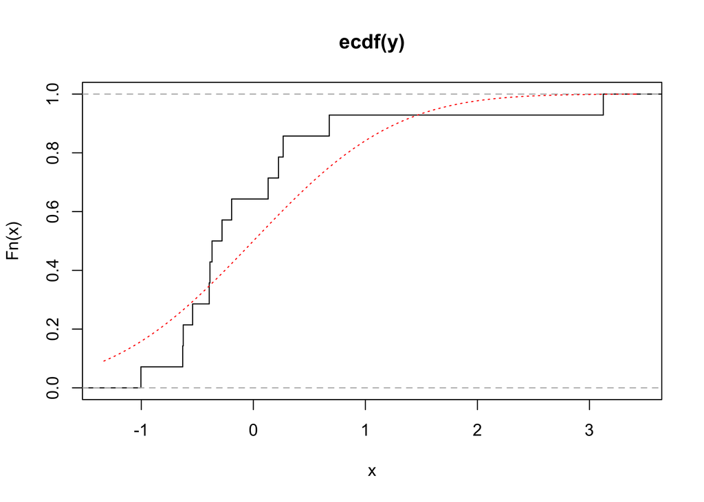

The normal CDF curve does not appear to be near “enough” to the empirical CDF. We can probably assume that the data is not normally distributed. Testing the normality hypothesis using the Shapiro-Wilk test we get a test stat of 0.7107667 and the p-value = $4.7869604\times 10^{-4}$. We reject the null hypothesis that the data is normally distributed. The Lilliefor’s test has a test statistic of 0.2522107 and a p-value of 0.0160568. We would come to the same conclusion using either test.

## 4.4

First, examining a historgram and a CDF plot we can start to get clues about the distribution of our data.

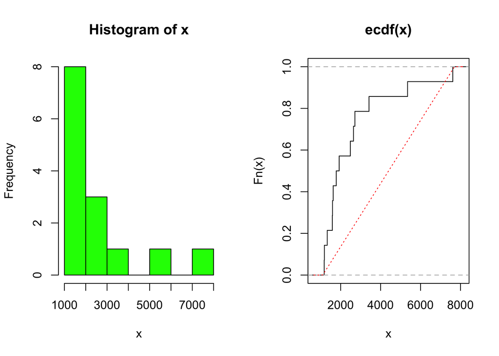

## 4.12

Here, we need to run a trend test. Using the Cox-Stuart test from the text, we find $p = 0.0703125$. There is weak evidence of a trend in the data. Visually, we can see this negative trend, albeit the test does show weak evidence, as does the plot. *Note: this is a two-sided p-value. If we suspected a negative or positve trend, we could run a one-sided test and our p value would be half 0.0703125*.

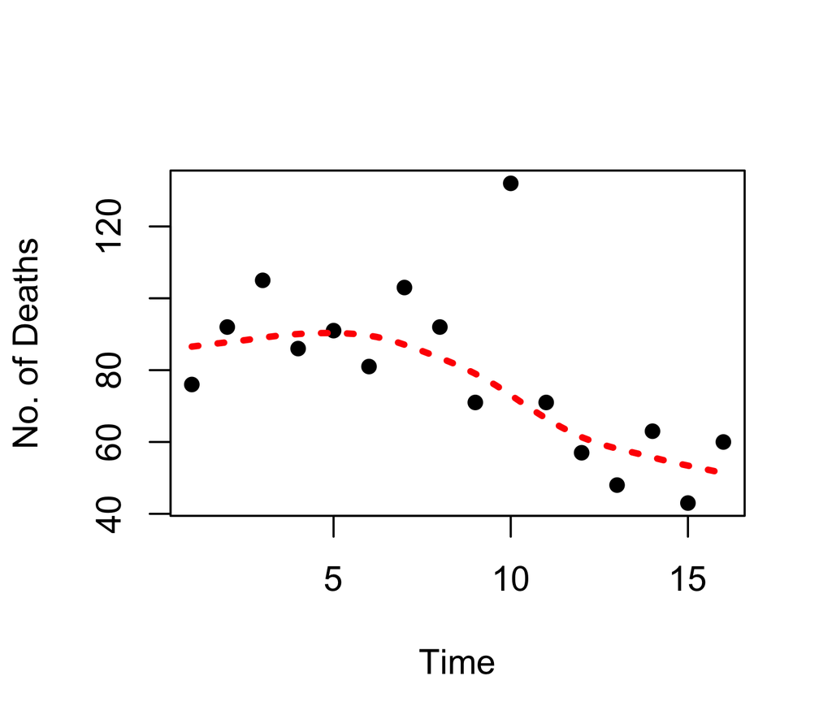

## 4.13

Visually looking at a plot of our data where the points are the locations on the road of the observed car accidents:

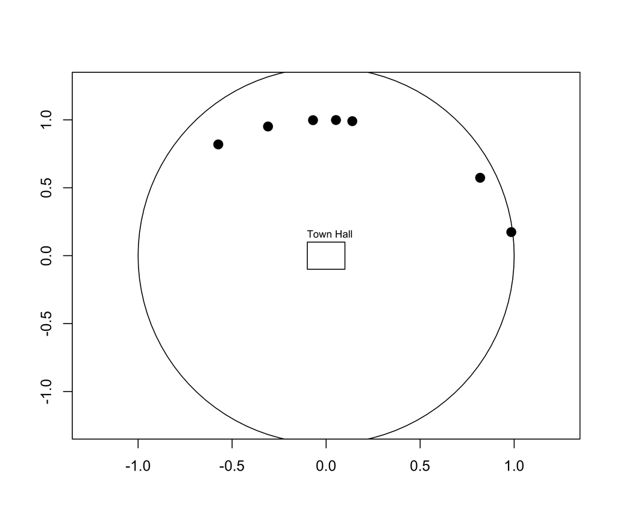

## 6.2

First, taking a look at a boxplt of the data for context:

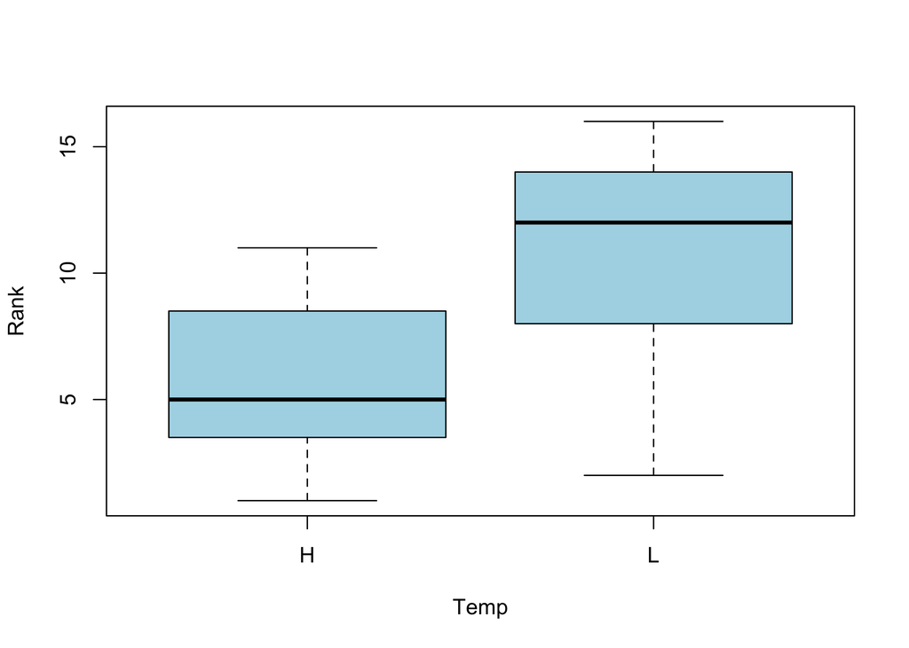

There may be evidence of a relationship between hardness and temperature, with the lower temperature creating harder specimins on average. Running a nonparametric test (WMW) we get $p = 0.0548951$. This is a “small” p-value albeit not “significant” at $\alpha = 0.05$. Further investation may be warranted.

## 6.4

There does not appear to be any real evience of a difference between the two insulations. The firms conclusions seem justified. A confidence interval contructing using the non-parametric method (WMW) contains zero [-0.2, 1.9]. Additionally, if we assume normality our conclusions do not change; 0 is also contained in the 95% confifence interval for the t test, [-0.1706533, 1.8289866].

## 6.10

Running a WMW test on the data and computing a confidence interval, we can see at significance level of 0.95, zero is NOT in our interval, [-17.42, -2.4]. There is evidence of a response difference between *dose I* and *dose II*.

## 6.11

Using these results
$$E(W) = \frac{n(m+n+1)}{2}$$
$$V(W) = \frac{mn(m+n+1)}{12}$$
$$Z = \frac{W_{mn} - E(W)}{\sqrt{V(W)}}$$
we compute the asymptotic z statistic $z = -2.8322445$ and the two-tailed probability of z is $p = 0.0046222$. We conclude that there is a difference between DMF scores for males and females among first year dental students.

There are quite a few ties. This could sway which test statistic is appropriate to use. However, the data does not appear to be grouped so I believe $U_m$ is an appropriate statistic here, using mid-ranks for ties.

## 6.13

Running some R code, I rank the data according to the *Seigel-Tukey* test, after shifting the **male** values by the mean of x minus the mean of y, 58.375.

|  | Rank |
| --- | --- |
| 47 | 1 |
| 105 | 4 |
| 118.625 | 5 |
| 126 | 8 |
| 141.625 | 9 |
| 142 | 12 |
| 158 | 13 |
| 168.625 | 16 |
| 171.625 | 17 |
| 172 | 20 |
| 173.625 | 19 |
| 197 | 18 |
| 209.625 | 15 |
| 213.625 | 14 |
| 220 | 11 |
| 225 | 10 |
| 230 | 7 |
| 238.625 | 6 |
| 262 | 3 |
| 270 | 2 |

We do NOT reject the null hypothesis that the variances are equal. The test statistic is 65 and the p-value is 0.2082877. Also I report the value $s_m = 101$.

## 6.15

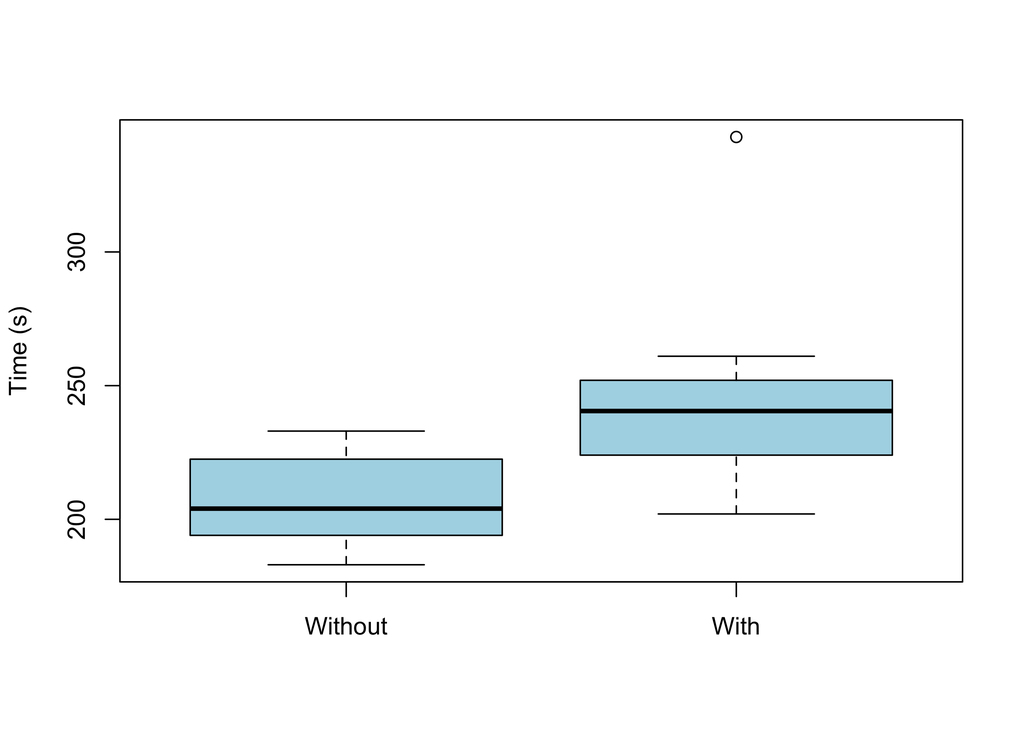

By visual inspection, it appears there is a difference between the two samples. Plotting the CDF of both samples below we see that they are not the same. Additionally, since one sample is greater than the other at every step of the CDF, a one test may be appropriate here. But, using tables provided, I report the two-tailed p-value. Having said that, there are other ways to run the test and get a p-value for a “greater” than alternative hypothesis and the results are not too different.

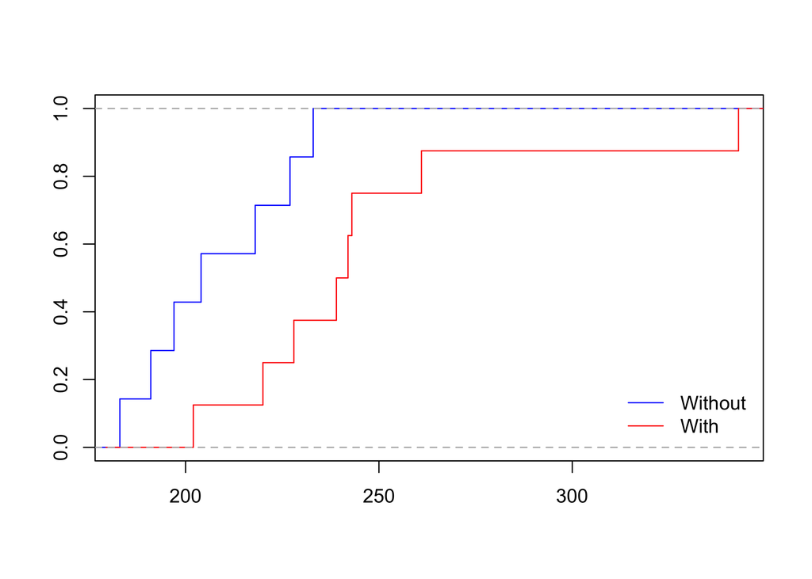

And using a Smirnov test where the psycologist believes these two samples are from different populations we find that

the probability that x lies above y is 0.0559441. We do not reject, although there may be some evidence of a difference between the two groups.

## 6.16

I’d like to first plof the empirical CDF of both samples.

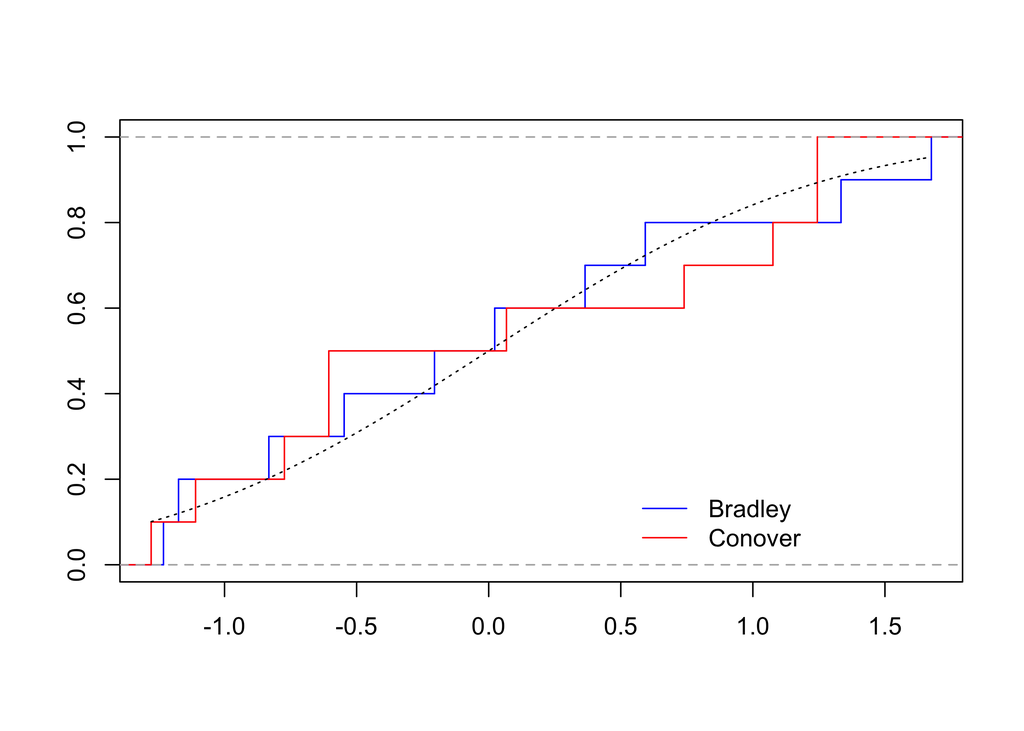

First off, it appears that both ecdfs follow the normal cdf very closely. This indicates that both samples are approximately normally distributed. If we can assume normality, we can run tests based on this assumption. But, for purposes of practice I run nonparametric tests on the samples.

- 1. I run a wilcox test where the sum of the x observations is 120.5 and $m = 10$. There are ties among the data, which means our p value will not be exact when looking it up uisng the provided tables. However, the exact p-value and the table p-value do not differ greatly to cause any concerns. Computing a two-sided p value we get $p = 0.2474507$. We can not reject the null hypothesis, $H_0: \eta_1 = \eta_2$.
- 2. At first glance, it appears that there may be a difference in variance among the two samples. Running a non-parametric test for variance, here I use the Siegel-Tukey test, we find that there is evidence to reject the null hypothesis. Interestingly, both the F test and the Siegel-Tukey test both reject the null hypotheis. Using either test, we would conclude the same.

  | obs | Rank |
  | --- | --- |
  | 13 | 1.0 |
  | 14 | 4.0 |
  | 17 | 5.0 |
  | 18 | 8.0 |
  | 20 | 10.5 |
  | 21 | 14.5 |
  | 25 | 18.5 |
  | 29 | 19.0 |
  | 31 | 16.5 |
  | 32 | 12.5 |
  | 35 | 10.0 |
  | 41 | 7.0 |
  | 45 | 6.0 |
  | 58 | 3.0 |
  | 64 | 2.0 |

- 3. There is not evidence to conclude that the distributions are different. Test statistic is 0.5. Looking up $mn(0.5) = 50$ on an appropriate table shows the p-value is 0.2. *Note, there are ties so this p-value is not exact*.
- 4. There is NOT evidence to conclude that data isn’t normally distributed. Shapiro-Wilk, KS test, and Lilliefor’s test all conclude the same.

## 6.17